# 2B. Data Exploration: Seasonality

```python
import pandas as pd
import matplotlib
import matplotlib.pyplot as plt
import matplotlib.cm as cmx
import matplotlib.colors as colors
import seaborn as sb
import numpy as np
import datetime as dt
import csv
from datetime import datetime
%matplotlib inline
```

## Overall Goal:

The goal of the seasonality analysis is to flush out the model that we used for predicting AirBnB pricing. Prices obviously change over time, so this added level of specificity makes the model that much more usable. Obviously, this is a problem that AirBnB has been actively trying to incorporate into their pricing analysis. While we did seem a high level of predictive power for our model, to be able to generalize it to an entire year instead of one snapshot at a specific date is obviously very important. Also, we are hoping with the seasonal nature of the data, utilizing such analysis will help decrease the residuals of our predictors by allowing for more detailed predictions based on more factors.

```python
#Importing Datafile and converting to numbers
data = pd.read_csv('../datasets/calendar_clean.csv')
data['new price']=data['new price'].str.lstrip('$').astype(float)
data['date']=pd.to_datetime(data['date'])
data['weekday'] = pd.Series(data.date).dt.dayofweek
```

This is what the dataset looks like right now. We needed to make changes to turn price into a float, date into a Python Datetime object, and create a column telling us what day of the week each date represents in the "day of week" column

```python
data.head(5)
```

|  | listing_id | date | available | new price | weekday |
| --- | --- | --- | --- | --- | --- |
| 0 | 3604481.0 | 2015-01-01 | t | 600.0 | 3 |
| 1 | 3604481.0 | 2015-01-02 | t | 600.0 | 4 |
| 2 | 3604481.0 | 2015-01-03 | t | 600.0 | 5 |
| 3 | 3604481.0 | 2015-01-04 | t | 600.0 | 6 |
| 4 | 3604481.0 | 2015-01-05 | t | 600.0 | 0 |

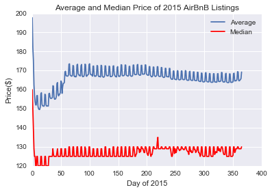

```python
#Taking average/median values as well as plotting
date=[]
avg_price=[]
median_price=[]
for i in data['date'].unique():
    date.append(i)
    avg_price.append(data[data['date'] == i]['new price'].mean())
    median_price.append(data[data['date'] == i]['new price'].median())
plt.plot(range(len(avg_price)), avg_price, label= "Average")
plt.plot(range(len(avg_price)),median_price,color='red', label = "Median")
plt.ylabel('Price($)')
plt.xlabel('Day of 2015')
plt.title('Average and Median Price of 2015 AirBnB Listings')
plt.legend()
```

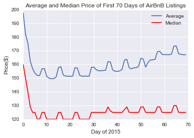

```python
plt.plot(range(len(avg_price[0:70])), avg_price[0:70], label= "Average")
plt.plot(range(len(avg_price[0:70])),median_price[0:70],color='red', label = "Median")
plt.ylabel('Price($)')
plt.xlabel('Day of 2015')
plt.title('Average and Median Price of First 70 Days of AirBnB Listings')
plt.legend()
```

Here, we can clearly see the weekly cyclicality trends of the data. Obviously there is a difference between the mean and median prices, but overall the trend is very much similar. Thus, we can move forward with the average AirBnB price because that is what all our baseline/ensemblem models are predicting. Thus, we want to be able to make changes to that predicted average. Clearly there are peaks around once every 7 days: 7, 14, 21, etc. Thus, we will look at days of the week first and see how that impacts the average AirBnB prices.

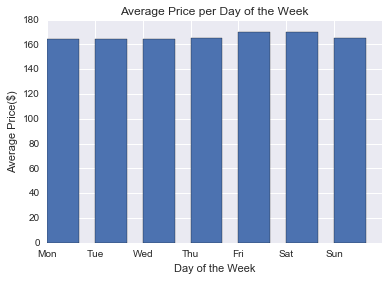

```python
daily_avg_price=[]
daily_median_price=[]
b=['Mon','Tue','Wed','Thu','Fri','Sat','Sun']
for i in range(7):
    daily_avg_price.append(data[data['weekday'] == i]['new price'].mean())
    daily_median_price.append(data[data['weekday'] == i]['new price'].median())
plt.bar(range(len(daily_avg_price)),daily_avg_price,1/1.5)
plt.xticks(range(len(daily_avg_price)),b)
plt.ylabel('Average Price($)')
plt.xlabel('Day of the Week')
plt.title('Average Price per Day of the Week')
```

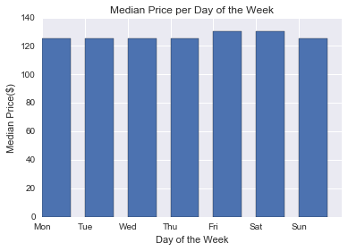

```python
plt.bar(range(len(daily_avg_price)),daily_median_price,1/1.5)
plt.xticks(range(len(daily_avg_price)),b)
plt.ylabel('Median Price($)')
plt.xlabel('Day of the Week')
plt.title('Median Price per Day of the Week')
```

```python
multiplier = []
for i in range(7):
    multiplier.append(daily_avg_price[i]/daily_avg_price[0])
```

```python
multiplier
```

```
[1.0,
 0.999677044441654,
 0.999581906843472,
 1.001452750623622,
 1.0314801624309469,
 1.031393687509484,
 1.0023139513392798]
```

```python
pricing_data=dict.fromkeys(b)
```

```python
for i in pricing_data:
    pricing_data[i]=[]
```

```python
## Alternate version where
listing_id=[]
for i in data['listing_id'].unique():
    listing_id.append(i)
    for index,j in enumerate(b):
        pricing_data[j].append(data[(data['weekday'] == index) & (data['listing_id'] == i)]['new price'].mean())
```

```python
results = pd.DataFrame(pricing_data)
results['listing_id'] = listing_id
results_nona = results.dropna(axis = 0)
results_nona = results_nona[['Mon', 'Tue', 'Wed', 'Thu', 'Fri', 'Sat', 'Sun', 'listing_id']]
```

```python
results_nona
```

|  | Mon | Tue | Wed | Thu | Fri | Sat | Sun | listing_id |
| --- | --- | --- | --- | --- | --- | --- | --- | --- |
| 0 | 600.000000 | 600.000000 | 600.000000 | 600.000000 | 600.000000 | 600.000000 | 600.000000 | 3604481.0 |
| 1 | 100.000000 | 100.000000 | 100.000000 | 100.000000 | 100.000000 | 100.000000 | 100.000000 | 2949128.0 |
| 2 | 70.576923 | 70.000000 | 70.000000 | 70.566038 | 80.384615 | 80.384615 | 70.576923 | 4325397.0 |
| 3 | 275.000000 | 275.000000 | 275.000000 | 275.000000 | 275.000000 | 275.000000 | 275.000000 | 4325398.0 |
| 4 | 110.697674 | 109.756098 | 110.138889 | 111.184211 | 112.361111 | 111.944444 | 110.581395 | 3426149.0 |
| 5 | 97.000000 | 97.000000 | 97.000000 | 97.000000 | 97.000000 | 97.000000 | 97.000000 | 65562.0 |
| 6 | 58.000000 | 58.000000 | 58.000000 | 58.000000 | 58.000000 | 58.000000 | 58.000000 | 2730672.0 |
| 7 | 55.000000 | 55.000000 | 55.000000 | 55.000000 | 55.000000 | 55.000000 | 55.000000 | 4587554.0 |
| 8 | 70.000000 | 70.000000 | 70.000000 | 70.000000 | 70.000000 | 70.000000 | 70.000000 | 819206.0 |
| 10 | 260.931818 | 256.521739 | 258.711111 | 268.045455 | 280.333333 | 283.133333 | 260.409091 | 2359340.0 |
| 11 | 150.000000 | 150.000000 | 150.000000 | 150.000000 | 150.000000 | 150.000000 | 150.000000 | 4653104.0 |
| 12 | 442.500000 | 440.000000 | 440.000000 | 440.000000 | 439.655172 | 439.655172 | 442.500000 | 3276860.0 |
| 13 | 100.000000 | 100.000000 | 100.000000 | 101.351351 | 101.388889 | 101.351351 | 101.351351 | 3604551.0 |
| 14 | 48.860000 | 49.000000 | 49.000000 | 49.000000 | 48.860000 | 48.860000 | 48.860000 | 3997768.0 |
| 15 | 100.000000 | 100.000000 | 100.000000 | 100.000000 | 130.000000 | 130.000000 | 100.000000 | 4128844.0 |
| 16 | 50.000000 | 50.000000 | 50.000000 | 50.000000 | 50.000000 | 50.000000 | 50.000000 | 185698.0 |
| 17 | 320.000000 | 320.000000 | 320.000000 | 320.566038 | 320.000000 | 320.000000 | 320.000000 | 3866715.0 |
| 18 | 100.000000 | 100.000000 | 100.000000 | 100.000000 | 100.000000 | 100.000000 | 100.000000 | 2752604.0 |
| 19 | 168.000000 | 168.000000 | 168.000000 | 168.000000 | 168.000000 | 168.000000 | 168.000000 | 262238.0 |
| 21 | 101.372549 | 101.960784 | 102.000000 | 101.400000 | 101.764706 | 102.000000 | 101.938776 | 4325480.0 |
| 22 | 65.000000 | 65.000000 | 65.000000 | 65.000000 | 65.000000 | 65.000000 | 65.000000 | 1048682.0 |
| 23 | 115.000000 | 115.000000 | 115.000000 | 115.000000 | 115.000000 | 115.000000 | 115.000000 | 1835122.0 |
| 24 | 104.285714 | 100.000000 | 100.000000 | 100.000000 | 100.000000 | 105.000000 | 104.285714 | 65660.0 |
| 25 | 180.000000 | 180.000000 | 180.000000 | 180.000000 | 180.000000 | 180.000000 | 180.000000 | 3801214.0 |
| 26 | 165.000000 | 165.000000 | 165.000000 | 165.000000 | 165.000000 | 165.000000 | 165.000000 | 3932288.0 |
| 27 | 150.000000 | 150.000000 | 150.000000 | 150.000000 | 150.000000 | 150.000000 | 150.000000 | 4653187.0 |
| 28 | 110.000000 | 110.000000 | 110.000000 | 110.000000 | 125.000000 | 125.000000 | 110.000000 | 327816.0 |
| 29 | 125.000000 | 125.000000 | 125.000000 | 125.000000 | 125.000000 | 125.000000 | 125.000000 | 753687.0 |
| 30 | 85.000000 | 85.000000 | 85.000000 | 85.000000 | 110.000000 | 110.000000 | 85.000000 | 4653196.0 |
| 31 | 150.000000 | 150.000000 | 150.000000 | 150.000000 | 150.000000 | 150.000000 | 150.000000 | 1704079.0 |
| ... | ... | ... | ... | ... | ... | ... | ... | ... |
| 2783 | 200.000000 | 200.000000 | 200.000000 | 200.000000 | 200.000000 | 200.000000 | 200.000000 | 1586304.0 |
| 2784 | 75.000000 | 75.000000 | 75.000000 | 75.000000 | 75.000000 | 75.000000 | 75.000000 | 4666498.0 |
| 2785 | 795.000000 | 795.000000 | 795.000000 | 795.000000 | 795.000000 | 795.000000 | 795.000000 | 1586307.0 |
| 2786 | 110.000000 | 110.000000 | 110.000000 | 110.000000 | 110.000000 | 110.000000 | 110.000000 | 1881556.0 |
| 2787 | 140.000000 | 140.000000 | 140.000000 | 140.000000 | 141.603774 | 141.634615 | 141.634615 | 4469911.0 |
| 2788 | 200.000000 | 200.000000 | 200.000000 | 200.000000 | 200.943396 | 200.961538 | 200.961538 | 4404384.0 |
| 2789 | 60.000000 | 60.000000 | 60.000000 | 60.000000 | 60.000000 | 60.000000 | 60.000000 | 2176166.0 |
| 2790 | 550.000000 | 550.000000 | 550.000000 | 550.000000 | 550.000000 | 550.000000 | 550.000000 | 4076712.0 |
| 2791 | 220.588235 | 219.711538 | 219.711538 | 220.192308 | 220.192308 | 220.098039 | 220.588235 | 13488.0 |
| 2792 | 183.000000 | 183.000000 | 183.000000 | 183.000000 | 183.000000 | 183.000000 | 183.000000 | 4666550.0 |
| 2793 | 99.000000 | 99.000000 | 99.000000 | 99.000000 | 99.000000 | 99.000000 | 99.000000 | 1990175.0 |
| 2794 | 150.000000 | 150.000000 | 150.000000 | 150.000000 | 150.000000 | 150.000000 | 150.000000 | 1127619.0 |
| 2795 | 250.000000 | 250.000000 | 250.000000 | 250.000000 | 250.000000 | 250.000000 | 250.000000 | 3290309.0 |
| 2796 | 200.000000 | 200.000000 | 200.000000 | 200.000000 | 250.000000 | 250.000000 | 200.000000 | 3224777.0 |
| 2797 | 89.000000 | 89.000000 | 89.000000 | 89.000000 | 89.000000 | 89.000000 | 89.000000 | 2897100.0 |
| 2798 | 225.000000 | 225.000000 | 225.000000 | 225.000000 | 225.000000 | 225.000000 | 225.000000 | 4404433.0 |
| 2799 | 180.000000 | 180.000000 | 180.000000 | 180.000000 | 180.000000 | 180.000000 | 180.000000 | 3764849.0 |
| 2800 | 146.470588 | 145.882353 | 146.470588 | 146.470588 | 195.000000 | 195.000000 | 146.666667 | 3028184.0 |
| 2801 | 175.000000 | 175.000000 | 175.000000 | 175.000000 | 175.000000 | 175.000000 | 175.000000 | 3028186.0 |
| 2802 | 220.000000 | 220.000000 | 220.000000 | 220.000000 | 208.125000 | 220.000000 | 220.000000 | 3868879.0 |
| 2803 | 65.000000 | 65.000000 | 65.000000 | 65.000000 | 70.000000 | 70.000000 | 65.000000 | 3683551.0 |
| 2804 | 130.000000 | 130.000000 | 130.000000 | 130.000000 | 130.000000 | 130.000000 | 130.000000 | 3027838.0 |
| 2805 | 60.000000 | 60.000000 | 60.000000 | 60.000000 | 60.000000 | 60.000000 | 60.000000 | 1717499.0 |
| 2806 | 159.666667 | 159.666667 | 160.000000 | 160.000000 | 159.666667 | 159.655172 | 159.666667 | 3093762.0 |
| 2807 | 80.000000 | 80.000000 | 80.000000 | 80.000000 | 80.000000 | 80.000000 | 80.000000 | 1914115.0 |
| 2808 | 100.000000 | 100.000000 | 100.000000 | 100.000000 | 100.000000 | 100.000000 | 100.000000 | 3486983.0 |
| 2809 | 150.000000 | 150.000000 | 150.000000 | 150.000000 | 150.000000 | 150.000000 | 150.000000 | 2045194.0 |
| 2810 | 240.000000 | 240.000000 | 240.000000 | 240.000000 | 240.000000 | 240.000000 | 240.000000 | 2296024.0 |
| 2811 | 48.000000 | 48.000000 | 48.000000 | 48.000000 | 48.000000 | 48.000000 | 48.000000 | 1586454.0 |
| 2813 | 90.000000 | 90.000000 | 90.000000 | 90.000000 | 90.000000 | 90.000000 | 90.000000 | 4207906.0 |

2730 rows × 8 columns

Something we notice from the Seasonality data is that much of the average prices by listing actually dont fluctuate over time. This explains a lot of why the original changes we from the average prices(across all listings) by day overall is pretty similar-- with a max of around 3% higher on Fridays and Saturdays compared to monday. Looking at this table also allows us to see a lot of business appeal! The fact that so many listings are not fluctuating their prices based on the day of the week shows some pricing inconsistencies with we have established is a necessary phenomena-- dynamic pricing. The fact that so many of these Day of the Week averages for each listing are exactly the same suggests that these listings do not change their prices for any of the reason. Clearly, these listings could use the results of our analysis to incorporate dynamic pricing in their prices over time to help optimize their profits. We export the dataframe for use in our later modeling file.

```python
results_nona.to_csv("../datasets/seasonality_tomodel.csv",index=False)
```

```python
df = pd.DataFrame({'price':avg_price})
df.to_csv("../datasets/daily_price.csv",index=False)
```